# STAD37

Richard Zhen

Due: November 23, 2021, 11:00pm

```r
library("tidyverse")
library("readr")
library("dplyr")
```

## 1(a)

```r
# Reads the data from "a3_profile_data.txt" and sets it to the variable plasma
plasma <- read.table("a3_profile_data.txt", header = T)
# Displays the data frame
plasma
```

```
##    Group  x1  x2  x3
## 1      1 125 137 121
## 2      1 144 173 147
## 3      1 105 119 125
## 4      1 151 149 128
## 5      1 137 139 109
## 6      2  93 121 107
## 7      2 116 135 106
## 8      2 109  83 100
## 9      2  89  95  83
## 10     2 116 128 100
```

```r
# Creates two different subsets for group 1 and group 2
plasmag1 <- subset(plasma, Group == 1, select = c(x1,x2,x3))
plasmag2 <- subset(plasma, Group == 2, select = c(x1,x2,x3))
# Displays up to the first six entries of both group 1 and group 2
head(plasmag1)
```

```
##    x1  x2  x3
## 1 125 137 121
## 2 144 173 147
## 3 105 119 125
## 4 151 149 128
## 5 137 139 109
```

```r
head(plasmag2)
```

```
##     x1  x2  x3
## 6   93 121 107
## 7  116 135 106
## 8  109  83 100
## 9   89  95  83
## 10 116 128 100
```

```r
# Set the values of the rows and columns and displays them
p <- ncol(plasmag1)
p
```

```
## [1] 3
```

```r
n1 <- nrow(plasmag1)
n1
```

```
## [1] 5
```

```r
n2 <- nrow(plasmag2)
n2
```

```
## [1] 5
```

```r
# Calculates the column means of Group 1 and Group 2 and displays them
xbar1 <- colMeans(plasmag1)
xbar1
```

```
##    x1    x2    x3
## 132.4 143.4 126.0
```

```r
xbar2 <- colMeans(plasmag2)
xbar2
```

```
##    x1    x2    x3
## 104.6 112.4  99.2
```

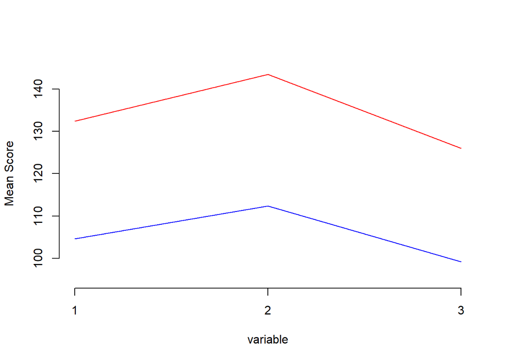

```r
# Plots and displays the profile graph and a line for Group 1
variable <- c(1,2,3)
plot(variable,xbar1,col = "red",ylab = "Mean Score" , axes = FALSE, type = "l", ylim = range(c(95,145)))
# Adjust the x-axis of the graph
axis(side = 1, at = variable)
# Adjust the y-axis of the graph
axis(side = 2)
# Creates a line for Graph 2
lines(variable,xbar2,col="blue")
```

What I have noticed in the plot is that the slopes of the lines are parallel to each other, the mean scores of Group 1 are greater than Group 2 mean scores, and that the lines/profiles are not overlaping/coincidient.

## 1(b)

Testing for parallel profiles

```r
# Calculates the variance-covariance of Group 1 and Group 2
S1 <- cov(plasmag1)
S2 <- cov(plasmag2)
# Display the variance-covariance of Group 1, Group 2, and pooled
S1
```

```
##        x1    x2     x3
## x1 326.80 285.8  66.75
## x2 285.80 390.8 191.00
## x3  66.75 191.0 190.00
```

```r
S2
```

```
##        x1     x2    x3
## x1 164.30 119.45  63.1
## x2 119.45 498.80 122.9
## x3  63.10 122.90  92.7
```

```r
Sp <- (1/(n1+n2-2))*((n1-1)*S1+(n2-1)*S2)
Sp
```

```
##         x1      x2      x3
## x1 245.550 202.625  64.925
## x2 202.625 444.800 156.950
## x3  64.925 156.950 141.350
```

```r
# Creates the contrast matrix
C<-matrix(c(-1,1,0,0,-1,1),byrow=TRUE,p-1,p)
# Displays the contrast matrix
C
```

```
##      [,1] [,2] [,3]
## [1,]   -1    1    0
## [2,]    0   -1    1
```

```r
C%*%(xbar1-xbar2)
```

```
##      [,1]
## [1,]  3.2
## [2,] -4.2
```

```r
# Sets to 90% confidence
alpha <- 0.05
# Calculates the Hotelling T^2 value for parallel
T_sq_parallel <- ((1/n1+1/n2)^(-1))*t(xbar1-
xbar2)%*%t(C)%*%solve(C%*%Sp%*%t(C))%*%C%*%(xbar1-xbar2)
# Displays the Hotelling T^2 value
T_sq_parallel
```

```
##           [,1]
## [1,] 0.1716331
```

```r
# Calculates the critcal value for parallel profiles
CritValue_parallel <- (((n1+n2-2)*(p-1))/(n1+n2-p))*qf(1-alpha, p-1, n1+n2-p)
# Displays the critcal value for parallel profiles
CritValue_parallel
```

```
## [1] 10.82838
```

For H_{01}: C{mu1} = C{mu2}, the critical value is greater than the T^2 value, we do not reject H01

Testing for coincident profiles

```r
# creates a column matrix of ones in the entries
one <- as.matrix(c(rep(1,p)))
# Displays the one matrix
one
```

```
##      [,1]
## [1,]    1
## [2,]    1
## [3,]    1
```

```r
# Calculates the Hotelling T^2 value for coincident
T_sq_coincident <- ((t(one)%*%(xbar1- xbar2))/sqrt((1/n1+1/n2)*(t(one)%*%Sp%*%one)))^2
# Displays the Hotelling T^2 value for coincident
T_sq_coincident
```

```
##          [,1]
## [1,] 10.89927
```

```r
# Calulates the critical value for coincident
CritValue_coincident <- qf(1-alpha, 1, n1+n2-2)
# Displays the critical value for coincident
CritValue_coincident
```

```
## [1] 5.317655
```

For H_{02}: 1'(mu1 - mu2), the critical value is less than than the T^2 value, we do reject H02

Therefore, the profiles are parallel but not coincident then we do not need to test if the profiles are levelled.

## 2(a)

```r
# Read the data from "1waymanova.txt" and sets it to the variable fish
fish <- read.table("1waymanova.txt", header = T)
# Displays the data
fish
```

```
##     x1  x2  x3  x4 Method
## 1  5.4 6.0 6.3 6.7      1
## 2  5.2 6.2 6.0 5.8      1
## 3  6.1 5.9 6.0 7.0      1
## 4  4.8 5.0 4.9 5.0      1
## 5  5.0 5.7 5.0 6.5      1
## 6  5.7 6.1 6.0 6.6      1
## 7  6.0 6.0 5.8 6.0      1
## 8  4.0 5.0 4.0 5.0      1
## 9  5.7 5.4 4.9 5.0      1
## 10 5.6 5.2 5.4 5.8      1
## 11 5.8 6.1 5.2 6.4      1
## 12 5.3 5.9 5.8 6.0      1
## 13 5.0 5.3 5.3 6.5      2
## 14 4.8 4.9 4.2 5.6      2
```

[output cut: 22 more lines]

```r
# Displays the sample means of each method
aggregate(fish[, 1:4], list(fish$Method), mean)
```

```
##   Group.1       x1       x2       x3       x4
## 1       1 5.383333 5.708333 5.441667 5.983333
## 2       2 5.258333 5.233333 5.308333 5.875000
## 3       3 4.975000 4.833333 5.908333 6.233333
```

## 2(b)

```r
#Creates subsets for each method
f1 <- subset(fish, Method==1)
f2 <- subset(fish, Method==2)
f3 <- subset(fish, Method==3)
# Sets the value of each row of the methods and displays them
n1 <- nrow(f1)
n2 <- nrow(f2)
n3 <- nrow(f3)
n <- n1+n2+n3
n1
```

```
## [1] 12
```

```r
n2
```

```
## [1] 12
```

```r
n3
```

```
## [1] 12
```

```r
n
```

```
## [1] 36
```

```r
# Variance-covariance matrix for method 1
S1 <- cov(f1[,1:4])
# Displays variance-covariance matrix for method 1
S1
```

```
##           x1        x2        x3        x4
## x1 0.3415152 0.1537879 0.2616667 0.2306061
## x2 0.1537879 0.1953788 0.2296212 0.2283333
## x3 0.2616667 0.2296212 0.4408333 0.3271212
## x4 0.2306061 0.2283333 0.3271212 0.4851515
```

```r
# Variance-covariance matrix for method 2
S2 <- cov(f2[,1:4])
# Displays variance-covariance matrix for method 2
S2
```

```
##           x1        x2        x3        x4
## x1 0.5826515 0.3587879 0.3721970 0.1915909
## x2 0.3587879 0.3296970 0.2496970 0.1781818
## x3 0.3721970 0.2496970 0.3535606 0.1611364
## x4 0.1915909 0.1781818 0.1611364 0.2675000
```

```r
# Variance-covariance matrix for method 3
S3 <- cov(f3[,1:4])
# Displays variance-covariance matrix for method 3
S3
```

```
##           x1        x2        x3        x4
## x1 0.2947727 0.1945455 0.1547727 0.1109091
## x2 0.1945455 0.2115152 0.1896970 0.1633333
## x3 0.1547727 0.1896970 0.2608333 0.1515152
## x4 0.1109091 0.1633333 0.1515152 0.2078788
```

## 2(c)

```r
# Calculates sum of squares and cross products matrix W
W <- (n1-1)*S1+(n2-1)*S2+(n3-1)*S3
# Displays W
W
```

```
##           x1       x2        x3        x4
## x1 13.408333 7.778333  8.675000  5.864167
## x2  7.778333 8.102500  7.359167  6.268333
## x3  8.675000 7.359167 11.607500  7.037500
## x4  5.864167 6.268333  7.037500 10.565833
```

## 2(d)

```r
# Total SS
T <- (n-1)*cov(fish[,1:4])
# Displays Total SS
T
```

```
##           x1        x2        x3        x4
## x1 14.458889  9.898333  7.299444  5.103889
## x2  9.898333 12.707500  5.019167  5.025833
## x3  7.299444  5.019167 13.989722  8.421944
## x4  5.103889  5.025833  8.421944 11.376389
```

```r
# Calculates sum of squares and cross products, B
B <- T-W
# Displays B
B
```

```
##            x1      x2        x3         x4
## x1  1.0505556  2.1200 -1.375556 -0.7602778
## x2  2.1200000  4.6050 -2.340000 -1.2425000
## x3 -1.3755556 -2.3400  2.382222  1.3844444
## x4 -0.7602778 -1.2425  1.384444  0.8105556
```

## 2(e)

```r
# Lambda value
lambda <- det(W)/(det(B+W))
lambda
```

```
## [1] 0.2200479
```

```r
# Populations
g <- 3
# Varibles
p <- 4
# Squaroots lambda value
lambda.sqrt <- sqrt(lambda)
# Calculates and displays test statistic
TestStat <- ((n-p-2)/(p))*((1-lambda.sqrt)/lambda.sqrt)
TestStat
```

```
## [1] 8.488314
```

```r
# Calculates and displays critical value
CritValue <- qf(1-0.05, 2*p, 2*(n-p-2))
CritValue
```

```
## [1] 2.096968
```

For H0: mu1 = mu2 = mu3, the critical value is less than the test statistic, we do reject H0.

## 2(f)

```r
# Calculates and displays test statistic
TestStat <- -(n-1-((p+g)/2))*log(lambda)
TestStat
```

```
## [1] 47.68817
```

```r
# Calculates and displays critical value
CritValue <- qchisq(p=1-0.05,df=p*(g-1))
CritValue
```

```
## [1] 15.50731
```

For H0: mu1 = mu2 = mu3, the critical value is less than the test statistic, we do reject H0.

## 3(a)

```r
# Read the data from "2sample_data.txt" and sets it to the variable skull
skull <- read.table("2sample_data.txt", header = T)
# Displays the data
skull
```

```
##     x1  x2  x3 x4 Period
## 1  131 138  89 49      1
## 2  125 131  92 48      1
## 3  131 132  99 50      1
## 4  119 132  96 44      1
## 5  136 143 100 54      1
## 6  138 137  89 56      1
## 7  139 130 108 48      1
## 8  125 136  93 48      1
## 9  131 134 102 51      1
## 10 134 134  99 51      1
## 11 129 138  95 50      1
## 12 134 121  95 53      1
## 13 126 129 109 51      1
## 14 132 136 100 50      1
```

[output cut: 46 more lines]

```r
# Displays the sample means of each period
aggregate(skull[,1:4], list(skull$Period), mean)
```

```
##   Group.1       x1    x2       x3       x4
## 1       1 131.3667 133.6 99.16667 50.53333
## 2       2 134.3667 131.7 98.06667 49.23333
```

## 3(b)

```r
#Creates subsets for each period
k1 <- subset(skull, Period==1)
k2 <- subset(skull, Period==2)
# Sets the value of each row of the periods and displays them
n1 <- nrow(f1)
n2 <- nrow(f2)
n3 <- nrow(f3)
n <- n1+n2+n3
n1
```

```
## [1] 12
```

```r
n2
```

```
## [1] 12
```

```r
n3
```

```
## [1] 12
```

```r
n
```

```
## [1] 36
```

```r
# Variance-covariance matrix for period 1
S1 <- cov(k1[,1:4])
# Displays variance-covariance matrix for period 1
S1
```

```
##           x1         x2         x3         x4
## x1 26.309195  4.1517241  0.4540230  7.2459770
## x2  4.151724 19.9724138 -0.7931034  0.3931034
## x3  0.454023 -0.7931034 34.6264368 -1.9195402
## x4  7.245977  0.3931034 -1.9195402  7.6367816
```

```r
# Variance-covariance matrix for period 2
S2 <- cov(k2[,1:4])
# Displays variance-covariance matrix for period 2
S2
```

```
##           x1        x2         x3        x4
## x1 23.136782  1.010345  4.7678161 1.8425287
## x2  1.010345 21.596552  3.3655172 5.6241379
## x3  4.767816  3.365517 18.8919540 0.1908046
## x4  1.842529  5.624138  0.1908046 8.7367816
```

```r
# Pooled variance-covariance matrix
Sp <- (1/(n1-1 + n2-1))*((n1-1)*S1 + (n2-1)*S2)
# Displays pooled variance-covariance matrix
Sp
```

```
##           x1        x2         x3         x4
## x1 24.722989  2.581034  2.6109195  4.5442529
## x2  2.581034 20.784483  1.2862069  3.0086207
## x3  2.610920  1.286207 26.7591954 -0.8643678
## x4  4.544253  3.008621 -0.8643678  8.1867816
```

## 3(c)

Box's M test

```r
# Population
g <- 2
# Variables
p <- 4
# Calculates and displays M
M <- ((n1+n2-2)*log(det(Sp))) - (((n1-1)*log(det(S1))) + ((n2-1)*log(det(S2))))
M
```

```
## [1] 4.155505
```

```r
# Calculates and displays u
u <- (1/(n1-1) + (1/(n2-1) -1/(n1+n2-2))) * (((2*p**2)+3*p-1)/(6*(p+1)*(g-1)))
u
```

```
## [1] 0.1954545
```

```r
# Calculates and displays the test statistic
TestStat <- (1-u)*M
TestStat
```

```
## [1] 3.343293
```

```r
# Calculates and displays the critical value
CritValue <- qchisq(p=1-0.05,df=(1/2)*p*(p+1)*(g-1))
CritValue
```

```
## [1] 18.30704
```

For H_0: Sum_1 = Sum_2, the critical value is greater than the test statistic, we do not reject H0

## 3(d)

```r
# Column means of each period
xbar1 <- colMeans(k1[,1:4])
xbar2 <- colMeans(k2[,1:4])
xbar1
```

```
##        x1        x2        x3        x4
## 131.36667 133.60000  99.16667  50.53333
```

```r
xbar2
```

```
##        x1        x2        x3        x4
## 134.36667 131.70000  98.06667  49.23333
```

```r
# create delta row matrix of zeros
delta <- c(0,0,0,0)
delta
```

```
## [1] 0 0 0 0
```

```r
# Calculates and displays T^2 value
T_sq <- t(xbar1-xbar2-delta)%*%solve((1/n1+1/n2)*Sp)%*%(xbar1-xbar2-delta)
T_sq
```

```
##        [,1]
## [1,] 6.3549
```

```r
# Calculates and displays critical value
criticalValue <- (((n1+n2-2)*p)/(n1+n2-p-1))*qf(1-0.05,p, n1+n2-p-1 )
criticalValue
```

```
## [1] 13.40892
```

```r
# Checks which linear combination is most responsible for the rejection
a <- solve(Sp)%*%(xbar1-xbar2)
a
```

```
##           [,1]
## x1 -0.17945450
## x2  0.07547477
## x3  0.06265372
## x4  0.23728097
```

## 3(e)

Bonferroni SCIs

```r
t <- qt(1-0.05/(p*g*(g-1)),df=n-g)
for(i in 1:p){
  LCI12 <- (xbar1[i]-xbar2[i])-t*sqrt(Sp[i,i]*(1/n1+1/n2))
  UCI12 <- (xbar1[i]-xbar2[i])+t*sqrt(Sp[i,i]*(1/n1+1/n2))
  cat("Bon SCI for mu1[",i,"]-mu2[",i,"] = (",LCI12,",",UCI12,")\n",sep="")
}
```

```
## Bon SCI for mu1[1]-mu2[1] = (-8.354074,2.354074)
## Bon SCI for mu1[2]-mu2[2] = (-3.009119,6.809119)
## Bon SCI for mu1[3]-mu2[3] = (-4.470196,6.670196)
## Bon SCI for mu1[4]-mu2[4] = (-1.780992,4.380992)
```

Bon SCI for mu1[1]-mu2[1] = (-8.354074,2.354074) Bon SCI for mu1[2]-mu2[2] = (-3.009119,6.809119) Bon SCI for mu1[3]-mu2[3] = (-4.470196,6.670196) Bon SCI for mu1[4]-mu2[4] = (-1.780992,4.380992)

SCIs

```r
c_square <- ((n1+n2-2)*p)/(n1+n2-p-1)*qf(1-0.05,df1 = p,df2 = n1+n2-p-1)
c <- sqrt(c_square)
for(i in 1:p){
LCI12 <- (xbar1[i]-xbar2[i])-c*sqrt(Sp[i,i]*(1/n1+1/n2))
UCI12 <- (xbar1[i]-xbar2[i])+c*sqrt(Sp[i,i]*(1/n1+1/n2))
cat("SCI for mu1[",i,"]-mu2[",i,"] = (",LCI12,",",UCI12,")\n",sep="")
}
```

```
## SCI for mu1[1]-mu2[1] = (-10.43313,4.43313)
## SCI for mu1[2]-mu2[2] = (-4.915392,8.715392)
## SCI for mu1[3]-mu2[3] = (-6.633174,8.833174)
## SCI for mu1[4]-mu2[4] = (-2.97738,5.57738)
```

SCI for mu1[1]-mu2[1] = (-10.43313,4.43313) SCI for mu1[2]-mu2[2] = (-4.915392,8.715392) SCI for mu1[3]-mu2[3] = (-6.633174,8.833174) SCI for mu1[4]-mu2[4] = (-2.97738,5.57738)

## 4(a)

```r
# Read the data from "t6_17.txt" and sets it to the variable nut
nut <- read.table("t6_17.txt", header = T)
# Displays the data
nut
```

```
##    Fac1 Fac2    x1    x2   x3
## 1     1    5 195.3 153.1 51.4
## 2     1    5 194.3 167.7 53.7
## 3     2    5 189.7 139.5 55.5
## 4     2    5 180.4 121.1 44.4
## 5     1    6 203.0 156.8 49.8
## 6     1    6 195.9 166.0 45.8
## 7     2    6 202.7 166.1 60.4
## 8     2    6 197.6 161.8 54.1
## 9     1    8 193.5 164.5 57.8
## 10    1    8 187.0 165.1 58.6
## 11    2    8 201.5 166.8 65.0
## 12    2    8 200.0 173.8 67.2
```

```r
# Observation vectors
p <- 3
# Levels for factor 1
g <- 2
# Levels for factor 2
b <- 3
# Observations per treatment
n <- 2
```

```r
fac1 <- factor(nut$Fac1)
fac2 <- factor(nut$Fac2)
nut345 <- as.matrix(nut[,3:5])
# Creates the fitted model
fit <- manova(nut345~fac1*fac2)
# Simulates the Wilks test
summary(fit,test = "Wilks")
```

```
##           Df    Wilks approx F num Df den Df   Pr(>F)
## fac1       1 0.106516  11.1843      3      4 0.020502 *
## fac2       2 0.012444  10.6191      6      8 0.001928 **
## fac1:fac2  2 0.074300   3.5582      6      8 0.050794 .
## Residuals  6
## ---
## Signif. codes:  0 '***' 0.001 '**' 0.01 '*' 0.05 '.' 0.1 ' ' 1
```

For fac1, H0: tau1 = tau2 = 0, the p-value 0.020502 is less than alpha = 0.05, we do reject H0

For fac2, H0: beta1 = beta2 = beta3 = 0, the p-value 0.001928 is less than alpha = 0.05, we do reject H0

For fac1:fac2, H0: gamma11 = gamma12 = gammaab = 0, the p-value 0.050794 is greater than alpha = 0.05, we do not reject H0

## 4(b)

```r
# Sum of squares and cross products matrices for SSPfac1
moreinfo <- summary(fit)
SSPfac1 <- moreinfo$SS[1]
SSPfac1
```

```
## $fac1
##             x1        x2          x3
## x1   0.7008333  -10.6575    7.129167
## x2 -10.6575000  162.0675 -108.412500
## x3   7.1291667 -108.4125   72.520833
```

```r
# Sum of squares and cross products matrices for SSPfac2
SSPfac2 <- moreinfo$SS[2]
SSPfac2
```

```
## $fac2
##          x1        x2       x3
## x1 196.1150  365.1825  42.6275
## x2 365.1825 1089.0150 414.6550
## x3  42.6275  414.6550 284.1017
```

```r
# Sum of squares and cross products matrices for SSPint
SSPint <- moreinfo$SS[[3]]
SSPint
```

```
##          x1       x2        x3
## x1 205.1017 363.6675 107.78583
## x2 363.6675 780.6950 254.22000
## x3 107.7858 254.2200  85.95167
```

```r
# Sum of squares and cross products matrices for SSPres
SSPres <- moreinfo$SS[[4]]
SSPres
```

```
##         x1      x2      x3
## x1 104.205  49.365  76.480
## x2  49.365 352.105 121.995
## x3  76.480 121.995  94.835
```

## 4(c)

```r
# Creates the fitted model
fit2 <- manova(nut345~fac1+fac2)
moreinfo2 <- summary(fit2)
```

```r
# Sum of squares and cross products matrices for SSPfac1
SSPfac1_2 <- moreinfo2$SS[1]
SSPfac1_2
```

```
## $fac1
##             x1        x2          x3
## x1   0.7008333  -10.6575    7.129167
## x2 -10.6575000  162.0675 -108.412500
## x3   7.1291667 -108.4125   72.520833
```

```r
# Sum of squares and cross products matrices for SSPfac2
SSPfac2_2 <- moreinfo2$SS[2]
SSPfac2_2
```

```
## $fac2
##          x1        x2       x3
## x1 196.1150  365.1825  42.6275
## x2 365.1825 1089.0150 414.6550
## x3  42.6275  414.6550 284.1017
```

```r
# Sum of squares and cross products matrices for SSPint
SSPres_2 <- moreinfo2$SS[3]
SSPres_2
```

```
## $Residuals
##          x1        x2       x3
## x1 309.3067  413.0325 184.2658
## x2 413.0325 1132.8000 376.2150
## x3 184.2658  376.2150 180.7867
```

```r
# SSPres + SSPint from the previouys part
SSPres+SSPint
```

```
##          x1        x2       x3
## x1 309.3067  413.0325 184.2658
## x2 413.0325 1132.8000 376.2150
## x3 184.2658  376.2150 180.7867
```

What I have observed is that SSPfac1 and SSPfac2 in this part and part b are the same. SSprese is equal to SSPres + SSPint from part with interaction of fac1 and fac2.